# Track Popularity Prediction Report

Data Science 2 with R (STAT 301-2)

Author

Stephanie Xu

## Introduction

What is the secret or tactic of making a hit song? Can we predict the public’s response to a song before it is released? For young musicians who want to gain more exposure and reputation, producing a hit song may be the best way to accomplish this goal.

The model can be used by either song creators or music labels who want to improve their performance in making a well-known song and can adjust the audio features of their music according to the parameters of the model before releasing songs.

## Data Overview

### Exploration of Missingness

At minimum the response variable should be explored and analyzed in detail. an inspection of the data for missingness and severe class imbalance of categorical data.

Data summary

| Name | spotify |
| --- | --- |
| Number of rows | 114000 |
| Number of columns | 21 |
| _______________________ |  |
| Column type frequency: |  |
| character | 4 |
| factor | 5 |
| numeric | 12 |
| ________________________ |  |
| Group variables | None |

**Variable type: character**

| skim_variable | n_missing | complete_rate | min | max | empty | n_unique | whitespace |
| --- | --- | --- | --- | --- | --- | --- | --- |
| track_id | 0 | 1 | 22 | 22 | 0 | 89741 | 0 |
| artists | 1 | 1 | 2 | 513 | 0 | 31437 | 0 |
| album_name | 1 | 1 | 1 | 243 | 0 | 46589 | 0 |
| track_name | 1 | 1 | 1 | 511 | 0 | 73608 | 0 |

**Variable type: factor**

| skim_variable | n_missing | complete_rate | ordered | n_unique | top_counts |
| --- | --- | --- | --- | --- | --- |
| explicit | 0 | 1 | FALSE | 2 | FAL: 104253, TRU: 9747 |
| key | 0 | 1 | TRUE | 12 | 7: 13245, 0: 13061, 2: 11644, 9: 11313 |
| mode | 0 | 1 | FALSE | 2 | 1: 72681, 0: 41319 |
| time_signature | 0 | 1 | TRUE | 5 | 4: 101843, 3: 9195, 5: 1826, 1: 973 |
| track_genre | 0 | 1 | FALSE | 114 | aco: 1000, afr: 1000, alt: 1000, alt: 1000 |

**Variable type: numeric**

| skim_variable | n_missing | complete_rate | mean | sd | p0 | p25 | p50 | p75 | p100 |
| --- | --- | --- | --- | --- | --- | --- | --- | --- | --- |
| x1 | 0 | 1 | 56999.50 | 32909.11 | 0.00 | 28499.75 | 56999.50 | 85499.25 | 113999.00 |
| popularity | 0 | 1 | 33.24 | 22.31 | 0.00 | 17.00 | 35.00 | 50.00 | 100.00 |
| duration_ms | 0 | 1 | 228029.15 | 107297.71 | 0.00 | 174066.00 | 212906.00 | 261506.00 | 5237295.00 |
| danceability | 0 | 1 | 0.57 | 0.17 | 0.00 | 0.46 | 0.58 | 0.70 | 0.98 |
| energy | 0 | 1 | 0.64 | 0.25 | 0.00 | 0.47 | 0.69 | 0.85 | 1.00 |
| loudness | 0 | 1 | -8.26 | 5.03 | -49.53 | -10.01 | -7.00 | -5.00 | 4.53 |
| speechiness | 0 | 1 | 0.08 | 0.11 | 0.00 | 0.04 | 0.05 | 0.08 | 0.96 |
| acousticness | 0 | 1 | 0.31 | 0.33 | 0.00 | 0.02 | 0.17 | 0.60 | 1.00 |
| instrumentalness | 0 | 1 | 0.16 | 0.31 | 0.00 | 0.00 | 0.00 | 0.05 | 1.00 |
| liveness | 0 | 1 | 0.21 | 0.19 | 0.00 | 0.10 | 0.13 | 0.27 | 1.00 |
| valence | 0 | 1 | 0.47 | 0.26 | 0.00 | 0.26 | 0.46 | 0.68 | 1.00 |
| tempo | 0 | 1 | 122.15 | 29.98 | 0.00 | 99.22 | 122.02 | 140.07 | 243.37 |

```
# A tibble: 1 × 21
     x1 track_id  artists album…¹ track…² popul…³ durat…⁴ expli…⁵ dance…⁶ energy
  <dbl> <chr>     <chr>   <chr>   <chr>     <dbl>   <dbl> <fct>     <dbl>  <dbl>
1 65900 1kR4gIb7… <NA>    <NA>    <NA>          0       0 FALSE     0.501  0.583
# … with 11 more variables: key <ord>, loudness <dbl>, mode <fct>,
#   speechiness <dbl>, acousticness <dbl>, instrumentalness <dbl>,
#   liveness <dbl>, valence <dbl>, tempo <dbl>, time_signature <ord>,
#   track_genre <fct>, and abbreviated variable names ¹album_name, ²track_name,
#   ³popularity, ⁴duration_ms, ⁵explicit, ⁶danceability
```

### Exploration of the Response Variable

The graph below reveals the distribution of the response variable `popularity`. It is a numerical variable and is left-skewed. One thing to be noticed is that among 114000 observations, more than 17500 have a `popularity` value of 0 which accounts for more than 1/10 of the total observations. This means that near 1/10 of the songs in the dataset are not popular at all.

Despite the zeros, the distribution of `poopularity` is slightly left skewed, so I won’t apply transformation to it. When splitting the dataset, `strata = popularity` is needed to deal with the issues with zeros.

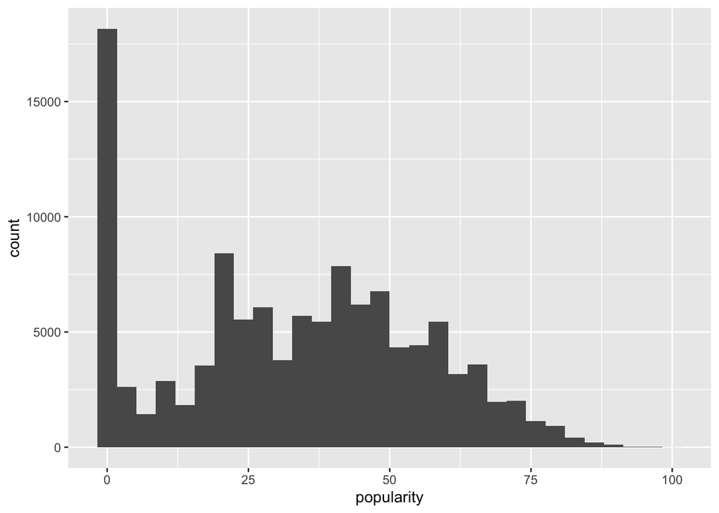

### Exploration of other categorical variables

#### `explicit`

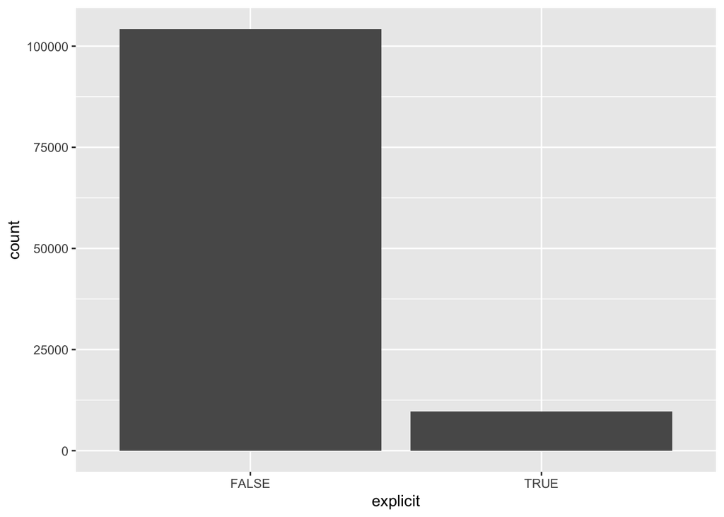

#### `track_genre`

The raw dataset takes 1000 samples for each genre, so categories of genre are well balanced.

```
# A tibble: 114 × 2
   track_genre     n
   <fct>       <int>
 1 acoustic     1000
 2 afrobeat     1000
 3 alt-rock     1000
 4 alternative  1000
 5 ambient      1000
 6 anime        1000
 7 black-metal  1000
 8 bluegrass    1000
 9 blues        1000
10 brazil       1000
# … with 104 more rows
```

#### `mode`

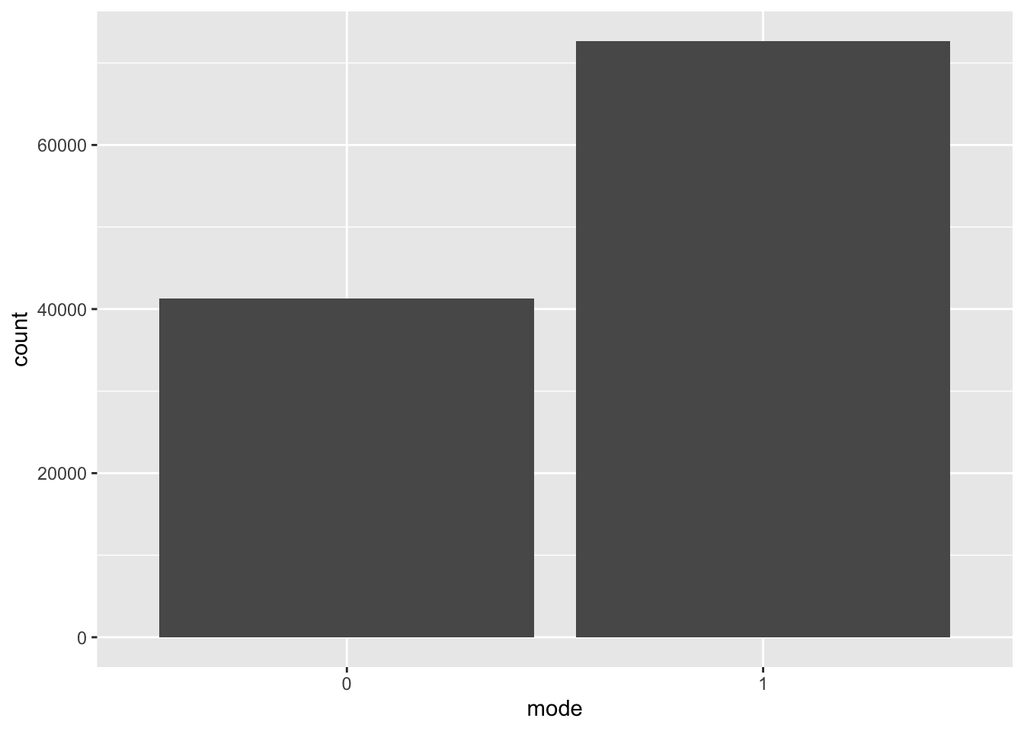

#### `key`

Variation exists in the number of tracks in each key. D♯/E♭ (represented by `3`) has the least number of tracks while C (`0`) and F♯/G♭ (`7`) have the most number of tracks.

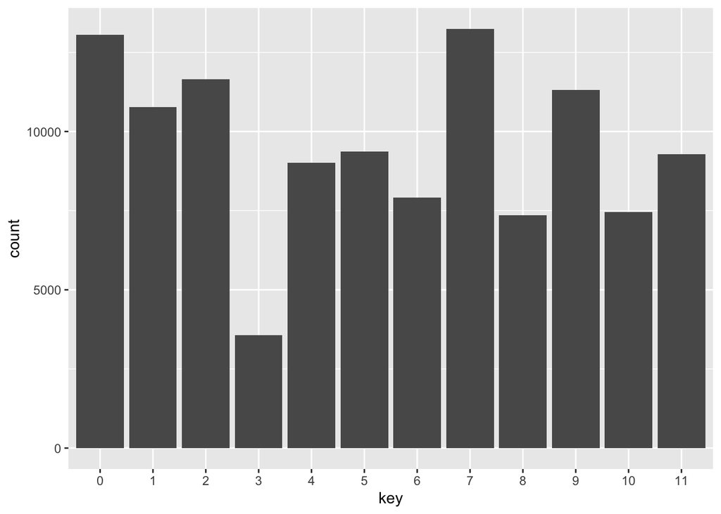

#### `time_signature`

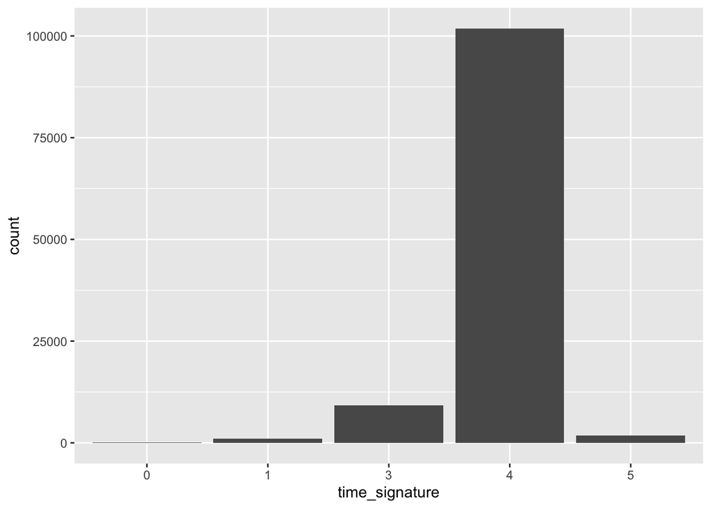

## Data spending

The ratio I chose to split the dataset is 0.65: 65% of the observation go to the training set and 35% of the observation goes to the testing dataset. The reasoning behind this is to save time while using the training dataset to tune parameters for models.

## Further EDA and feature engineering

### Correlation between numerical variables and `popularity`

The correlation between other numerical variables and `popularity` is shown in the graph below.

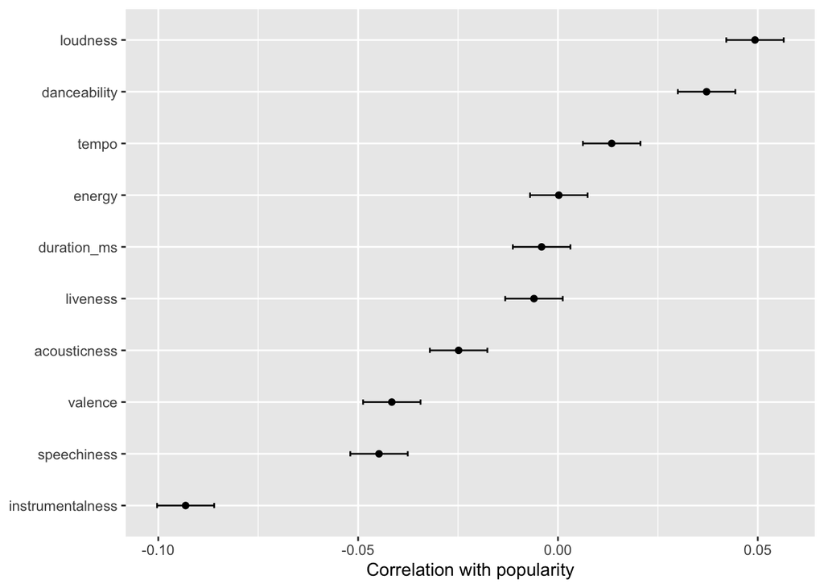

The six numerical variables that have the highest correlation with `popularity` are `instrumentalness`, `loudness`, `speechiness`, `valence`, `danceability` and `acousticness` (correlation from high to low). They are considered potential predictors for the model.

### Relationship between categorical variables and `popularity`

#### Relationship between `explicit` and `popularity`

The graph below shows the distribution of `popularity` in each `explicit` category.

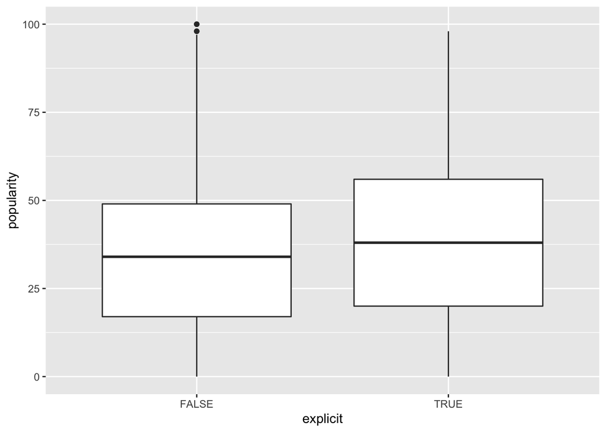

The median of `popularity` belongs to the `TRUE` category is higher than the `FALSE` category. In addition, when looking at the first and third quartile, those of the `TRUE` category are also greater than those of the `FALSE` category. Thus explicit tracks in general are more popular than non-explicit tracks. However, it is possible that higher overall `popularity` in the `TRUE` category is a result of severe class imbalance. To exclude this interference, I will not consider `explicit` as a predictor.

#### Relationship between `track_genre` and `popularity`

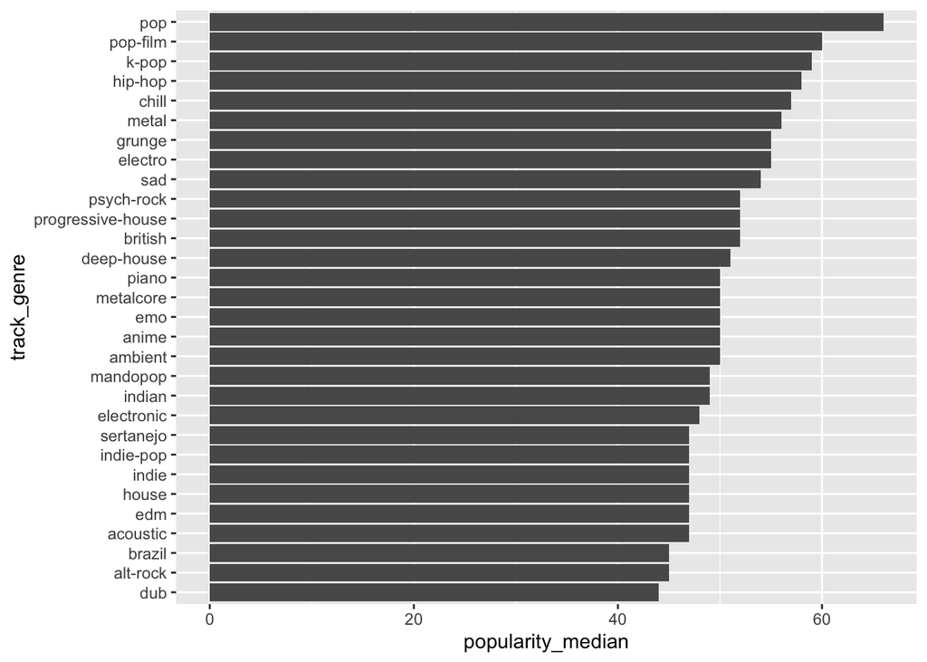

#### Relationship between `mode` and `popularity`

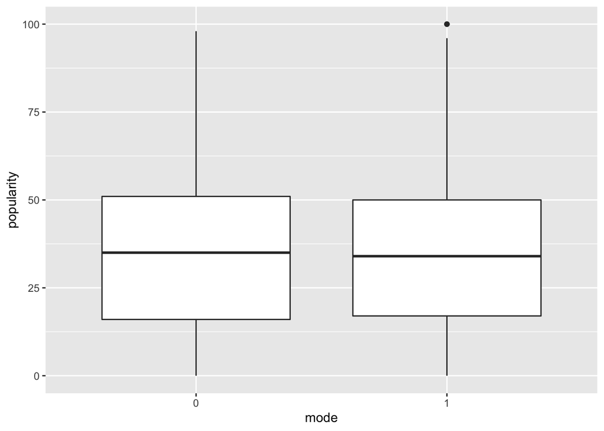

#### Relationship between `time_signature` and `popularity`

Variations in the medians of `popularity` of different `time_signature` exist when looking at the boxplot below. It is possible that `time_signature` can be used to predict `popularity`.

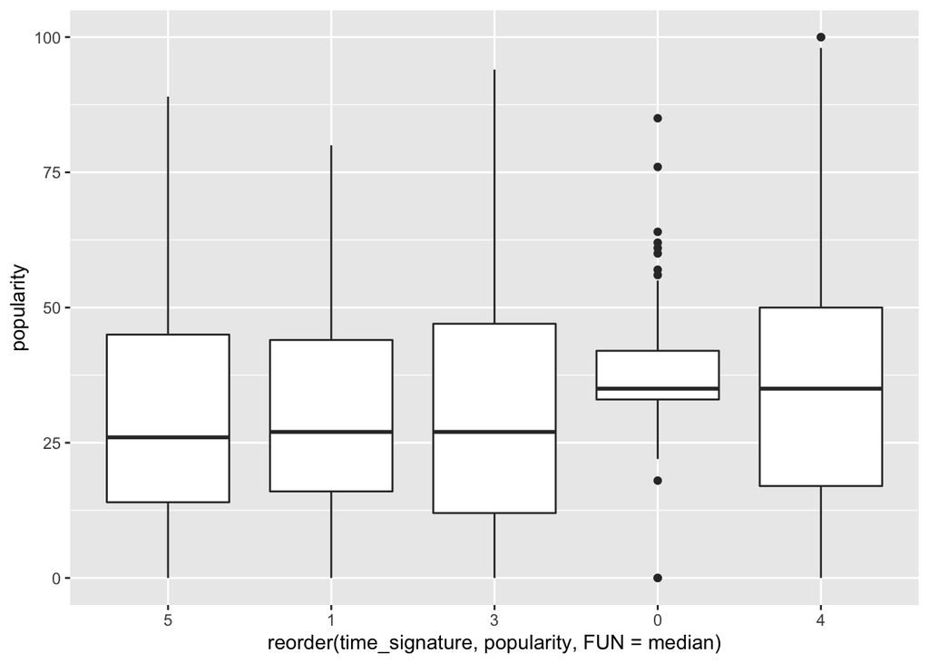

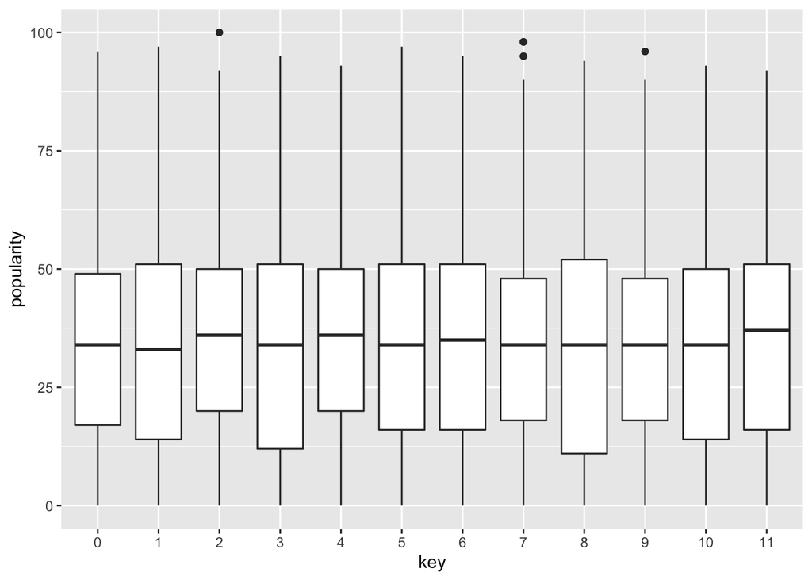

The medians of popularity don’t have significant variation for each key value, and thus `key` is not considered a predictor.

## Methods

### Recipes

- Recipe 1 is the standard/basic recipe for models. Predictors include six numerical predictors which have highest correlation with `popularity` in the correlation test- `instrumentalness`,`loudness`, `speechiness`, `valence`, `danceability`and `accousticness`- and one categorical predictor `time_signature`.
- Recipe 2 is the variation of Recipe 1. I remove `instrumentalness` from predictors to explore the importance of `instrumentalness` in predicting `popularity`.
- Recipe 3 is also the variation of Recipe 1. I remove `loudness` from predictors to explore the importance of `loudness` in predicting `popularity`

### Resampling Technique

I use cross-validation with 5 folds and 3 repeats as a resampling technique. During this process, the training dataset will be split into 5 folds. The model will be trained on 4 folds and tested on the other fold. The performance of the model on the testing fold will be recorded. Then the iteration continues until each folds has been used for testing once. This whole process will repeat for 3 times, giving a total of 5*3 = 15 estimations.

### Models and Model Setup

All the models I select were set to `regression` mode and for predictive purposes. The grid search method is applied for finding the optimal parameter. I chose a regular grid and 5 levels per parameter. However, for Random Forest and Boosted Tree, I set 3 levels per parameter to reduce the time spent on tuning.

#### Null Model

A null model is used to draw the baseline for the model performance. Any model have poorer performance than this baseline will be meaningless for prediction.

#### OLS linear regression

- This model chooses unknown parameters by the principle of least squares, that is minimizing the sum of the squares of the differences between true response variable and the predicted response variable.
- No parameter will be tuned.

#### Elastic Net Regularization

- Elastic net is a regularized regression method that linearly combines the L1 and L2 penalties of the lasso and ridge methods.
- `mixture` and `penalty` are two parameters need to be tuned. `mixture` determines the level of combination of lasso and ridge, and `penalty` determines the `penalty` value.

#### Kth Nearest Neighbor

- In KNN regression, given a query point, the algorithm finds the K training points that are closest to the query point in terms of some distance metric. It then takes the average (or median) of the target values of those K points and uses it as the predicted target value for the query point.
- `neighbors` is the parameter needs to be tuned.

### Evaluation metrics

- RMSE: it computes the root mean squared error between the actual response variable and the predicted response variable. The lower the RMSE value, the better the prediction.
- $R^2$: it measures how much variability in dependent variable can be explained by the model and ranges from 0 to 1. The closest the $R^2$ to 1, the better the estimation.

## Model Building & Selection

### Baseline

```
# A tibble: 2 × 7
  .metric .estimator  mean     n std_err .config              model
  <chr>   <chr>      <dbl> <int>   <dbl> <chr>                <chr>
1 rmse    standard    22.3    15  0.0117 Preprocessor1_Model1 null
2 rsq     standard   NaN       0 NA      Preprocessor1_Model1 null
```

The baseline is set by the RMSE and $R^2$ when a null model is used. Any model with RMSE greater than this value or $R^2$ smaller than this value will be considered meaningless for prediction. Note that the $R^2$ value of the null model is `NaN`, which probably indicates that there is no linear relationship between predictors and the response variable.

### Compare model performance for each recipe

#### Recipe1

```
# A tibble: 6 × 4
  model    .metric  mean std_err
  <chr>    <chr>   <dbl>   <dbl>
1 rf1      rmse     16.6  0.0287
2 bt1      rmse     18.1  0.0346
3 knn1     rmse     19.9  0.0335
4 elastic1 rmse     22.0  0.0164
5 lm1      rmse     22.0  0.0165
6 null     rmse     22.3  0.0117
```

```
# A tibble: 6 × 4
  model    .metric     mean   std_err
  <chr>    <chr>      <dbl>     <dbl>
1 rf1      rsq       0.447   0.00179
2 bt1      rsq       0.365   0.00192
3 knn1     rsq       0.260   0.00188
4 lm1      rsq       0.0239  0.000528
5 elastic1 rsq       0.0239  0.000528
6 null     rsq     NaN      NA
```

In Recipe1, Random Forest has the best performance: it has the lowest RMSE at 16.6292 and highest $R^2$ at 0.4468.

```
# A tibble: 1 × 8
   mtry min_n .metric .estimator  mean     n std_err .config
  <int> <int> <chr>   <chr>      <dbl> <int>   <dbl> <chr>
1     5     2 rmse    standard    16.6    15  0.0287 Preprocessor1_Model1
```

```
# A tibble: 1 × 8
   mtry min_n .metric .estimator  mean     n std_err .config
  <int> <int> <chr>   <chr>      <dbl> <int>   <dbl> <chr>
1     5     2 rsq     standard   0.447    15 0.00179 Preprocessor1_Model1
```

The optimal parameter for this model is when `mtry = 5` and `min_n = 2`.

#### Recipe2

```
# A tibble: 6 × 4
  model    .metric  mean std_err
  <chr>    <chr>   <dbl>   <dbl>
1 rf2      rmse     16.9  0.0250
2 bt2      rmse     18.5  0.0346
3 knn2     rmse     20.1  0.0244
4 elastic2 rmse     22.2  0.0144
5 lm2      rmse     22.2  0.0144
6 null     rmse     22.3  0.0117
```

```
# A tibble: 6 × 4
  model    .metric     mean   std_err
  <chr>    <chr>      <dbl>     <dbl>
1 rf2      rsq       0.427   0.00168
2 bt2      rsq       0.342   0.00198
3 knn2     rsq       0.245   0.00137
4 elastic2 rsq       0.0137  0.000390
5 lm2      rsq       0.0137  0.000390
6 null     rsq     NaN      NA
```

Random forest is the winning model with recipe2: it has the lowest RMSE at 16.9199 and highest $R^2$ at 0.4265.

```
# A tibble: 1 × 8
   mtry min_n .metric .estimator  mean     n std_err .config
  <int> <int> <chr>   <chr>      <dbl> <int>   <dbl> <chr>
1     5     2 rmse    standard    16.9    15  0.0250 Preprocessor1_Model1
```

```
# A tibble: 1 × 8
   mtry min_n .metric .estimator  mean     n std_err .config
  <int> <int> <chr>   <chr>      <dbl> <int>   <dbl> <chr>
1     5     2 rsq     standard   0.427    15 0.00168 Preprocessor1_Model1
```

The optimal parameters for this model is `mtry = 5`and `min_n = 2`

#### Recipe3

```
# A tibble: 6 × 4
  model    .metric  mean std_err
  <chr>    <chr>   <dbl>   <dbl>
1 rf3      rmse     16.8  0.0270
2 bt3      rmse     18.4  0.0345
3 knn3     rmse     20.0  0.0303
4 lm3      rmse     22.0  0.0164
5 elastic3 rmse     22.0  0.0164
6 null     rmse     22.3  0.0117
```

```
# A tibble: 6 × 4
  model    .metric     mean   std_err
  <chr>    <chr>      <dbl>     <dbl>
1 rf3      rsq       0.433   0.00161
2 bt3      rsq       0.346   0.00186
3 knn3     rsq       0.254   0.00144
4 lm3      rsq       0.0238  0.000524
5 elastic3 rsq       0.0238  0.000523
6 null     rsq     NaN      NA
```

Winning model is Random Forest with lowest mean RMSE at 16.8332 and highest mean $R^2$ at 0.4325.

```
# A tibble: 1 × 8
   mtry min_n .metric .estimator  mean     n std_err .config
  <int> <int> <chr>   <chr>      <dbl> <int>   <dbl> <chr>
1     5     2 rmse    standard    16.8    15  0.0270 Preprocessor1_Model1
```

```
# A tibble: 1 × 8
   mtry min_n .metric .estimator  mean     n std_err .config
  <int> <int> <chr>   <chr>      <dbl> <int>   <dbl> <chr>
1     5     2 rsq     standard   0.433    15 0.00161 Preprocessor1_Model1
```

The optimal parameters are `mtry = 5` and `min_n = 2`

#### Choosing Optimal Recipe and importance of predictors.

```
# A tibble: 6 × 3
# Groups:   recipe [3]
  recipe .metric metric_mean
   <dbl> <chr>         <dbl>
1      1 rmse         19.7
2      1 rsq           0.224
3      2 rmse         20.0
4      2 rsq           0.208
5      3 rmse         19.9
6      3 rsq           0.216
```

I calculated the mean RMSE and $R^2$ for each recipe. Recipe 1, the standard recipe is the winning recipe with lowest RMSE at 19.7481 and highest $R^2$ at 0.2237.

Recipe 2 is obtained by removing `intrumentalness` from predictors. The RMSE is increased by 0.22 and $R^2$ is decreased by 0.015 after doing this.

Both predictors have influences on the performance of the model, while `instrumentalness` is more important in predicting values for `popularity` compared to `loundess`.

### Best parameters for each model type

Here I visualize the change in RMSE when parameters change for each model. Only models tuned with Recipe 1 are chosen because Recipe 1 is the optimal recipe.

#### Random Forest

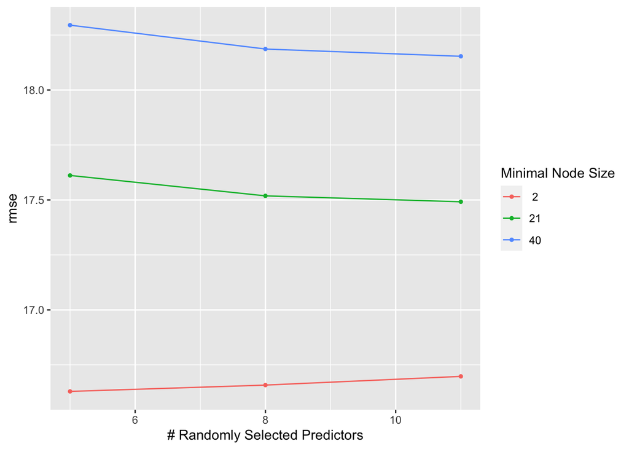

A pattern can be observed is that the smaller the minimal node size, the better the prediction. However, if the minimal node size is too small, it is possible to lead to overfitting.

For `mtry`, when minimal node size is at 21 and 40, increase in `mtry` can result in more accurate prediction. But it is not the case when minimal node size is at 2. The increase in `mtry` can make the prediction less accurate. As there are only three levels for `mtry` and `min_n`, a conclusion of how the change in parameters can affect performance of the model cannot be made due to lack of information.

#### Boosted Tree

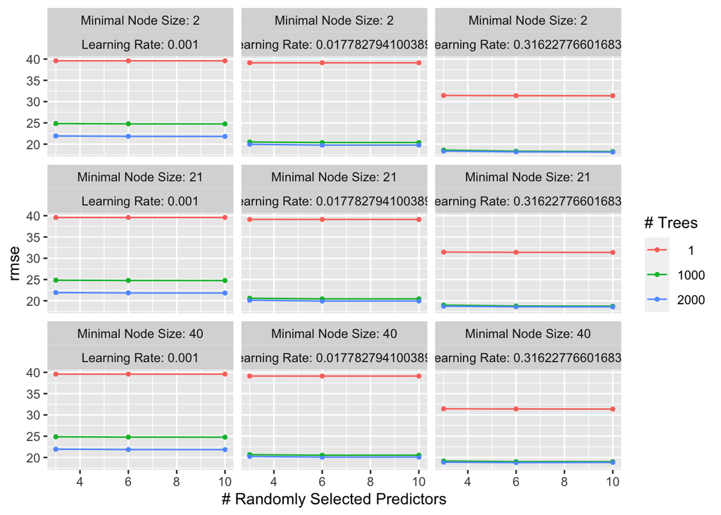

It is very clear that more `trees` (in thousands) will lead to better prediction. The influence of `learn rate` is also very obvious: higher learn rate can significantly reduce the RMSE. But from my results, the change in minimal node size doesn’t have very strong impact on the RMSE.

#### KNN

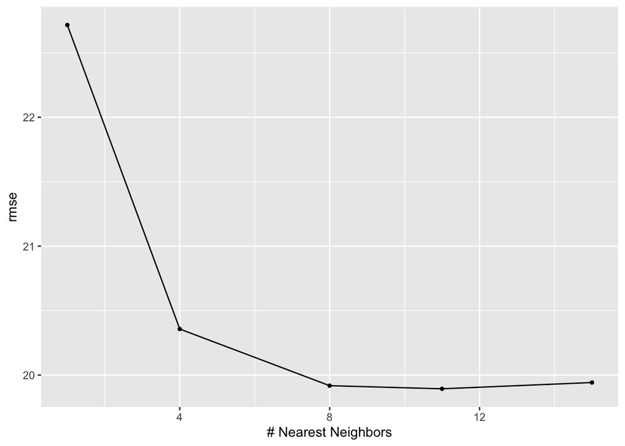

From the graph above, the RMSE decreases as the number of nearest neighbors increase. The change is most drastic when the number of nearest neighbor increases from 1 to 4, and the pace of decreasing slows down when the number of nearest neighbor is greater than 4.

#### Elastic Net

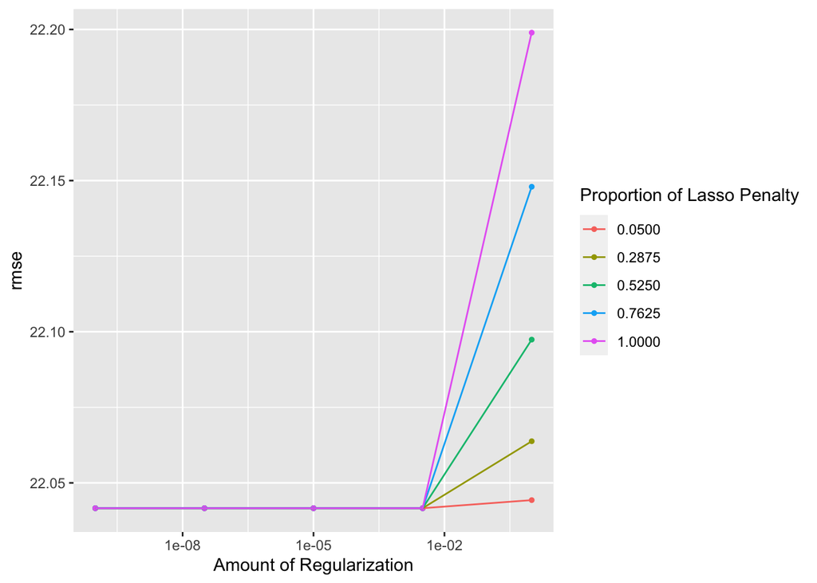

When the `penalty` is at a very small scales, the change of penalty have subtle impact on RMSE. Once the penalty is greater than a certain level, the increase of penalty lead to increase in RMSE.

The minimum RMSE occurs when the `mixture` is 0.0500. As `mixture` increases, the RMSE also increases.

### The winning model

After comparison above, I concluded that the random forest model with recipe 1 is the winning model, with parameters `mtry = 5` and `min_n = 2`. This model has the lowest RMSE and highest $R^2$ value, indicating that this model has the lowest estimation error and 44.68% of the variability observed in `popularity` is explained by the regression model.

The result is not surprising because the $R^2$ for null model `NaN`, indicating that there’s no linear relationship or very little linear relationship between predictors and `popularity`. The $R^2$ value of OLS models and Elastic Net Models ranges between 0.013 and 0.023, also implies that the linear relationship is very weak. In this situation, tree models and KNN model usually outperform the linear models.

## Final Model Analysis

At the final stage, I used the training dataset to fit the winning model- Random Forest with `trees = 1000`,`mtry = 5` and `min_n = 2` and Recipe 1 (predictors include `instrumentalness`,`loudness`, `speechiness`, `valence`, `danceability`, `accousticness` and `time_signature`). Next, the fitted model will be used to predict the `popularity` with the test dataset.

The performance of this final model is even better than the best performing random forest model at the validation stage.

```
# A tibble: 2 × 3
  .metric .estimator .estimate
  <chr>   <chr>          <dbl>
1 rmse    standard      16.1
2 rsq     standard       0.484
```

The RMSE is 0.5764 lower than the previous winning model, and the $R^2$ is 0.0373 higher than the previous one.

The following graph visualizes how well the model predict the `popularity`.

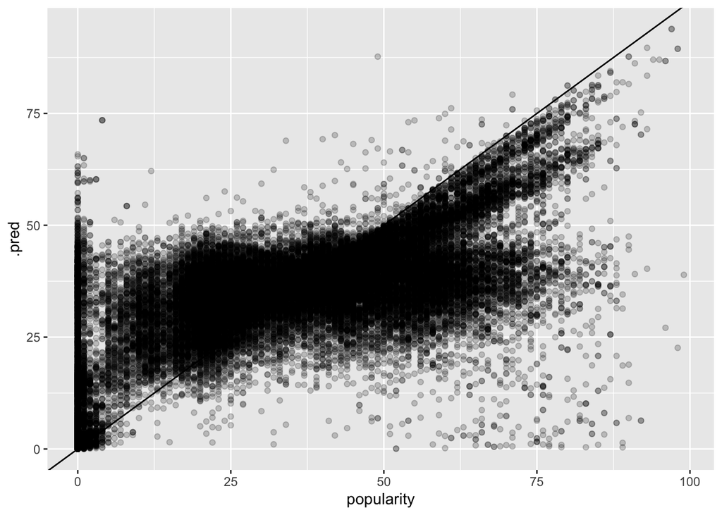

If the prediction is exactly the true value of `popularity`, all the data points will align on the solid line.

The following graph provides a closer look at the residuals.

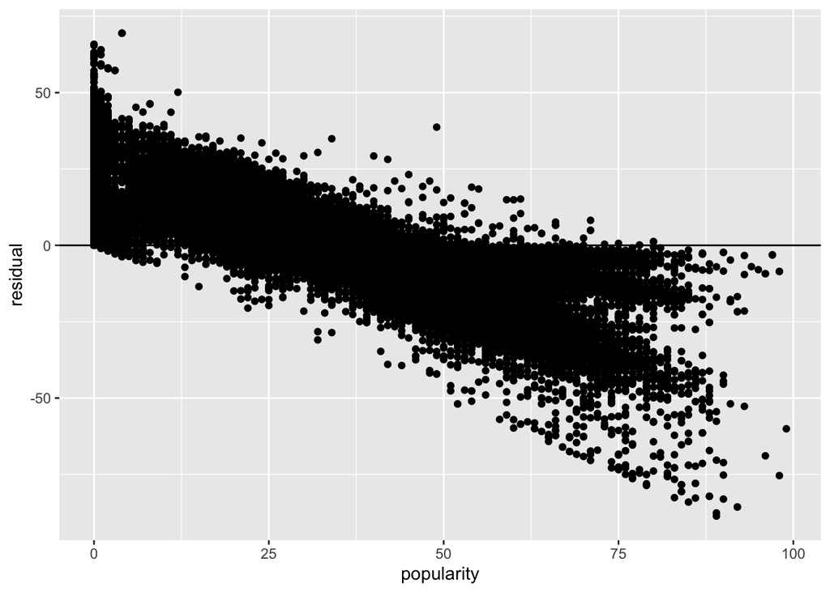

One group of residuals are along the zero line and the other implies a negative correlation between the response variable and residual. The negative trend that occurs in the residual plot indicates that the model fails to predict a portion of the `popularity` accurately. Further exploration of predictors and model selection and parameter tuning is needed if we want to optimize the predictability of the model.

## Conclusion

In order to predict the `popularity` of a song, this project shows that with predictors `instrumentalness`,`loudness`, `speechiness`, `valence`, `danceability`, `accousticness` and `time_signature`, the random forest model with `mtry = 5`, `min_n = 2` and `trees = 1000` is best at predicting the target variable.

In addition, the project also reveals that both `instrumentalness` and `loudness` are important predictors, while `instrumentalness` has more impact on the predictability of a model.

However, this model is not optimal. Results in the final analysis section show that improvement is needed for accurate prediction. Further exploration can focus on including the interaction of predictors in feature engineering or include `track_genre` as a predictor if the time is not a concern. Alternatively, instead of defining predicting `popularity` as a regression problem, I can transform the research question into a classification one. Response variable can consists of 5 categories each corresponds to range 0-20, 20-40, 40-60, 60-80 and 80-100. This transformation can potentially solve the issues with large amount of zero in `popularity`.

## Reference

Pandya, Maharshi. “Spotify Tracks Dataset.” Kaggle, 22 Oct. 2022, www.kaggle.com/datasets/maharshipandya/-spotify-tracks-dataset.